# Data on Cars used for Testing Fuel Economy

## by kourosh sadeghi

## Investigation Overview

in this exploration I found some perfect relationships between variables. the correlation between displ and city_mpg and hwy_mpg are approximately strong negative. corelation between displ and greenhouse gas score is approximately negative. we have other positive relation coefficient between greenhouse gas score and city_mpg and hwy_mpg. one of the biggest exploration in this dataset is negative relation between greenhouse gas score and displ. we found negative relation between number of engine cylinders and city_mpg, hwy_mpg and approximately greenhouse gas score. both of 2WD and 4WD have the same air pollution score, but for greenhouse gas score, we have this score for 4WD less than 2WD we find out standard SUV car has minimum rating in all of numeric variables. before this class of car, trend of these variables the trends have been almost upward

## Dataset Overview

The test data used to determine fuel economy is derived from vehicle testing done at EPA's National Vehicle and Fuel Emissions Laboratory in Ann Arbor, Michigan, and by vehicle manufacturers who submit their own test data to EPA. this dataset contains 832 rows with 13 features that shows properties about varieties of cars in 2018 sume of these features about model cars are: kind of fuel of car, number of engine cylinders, number of wheel Drive, vehicle classes and ...

## how many ordinal varables we have from their categories?

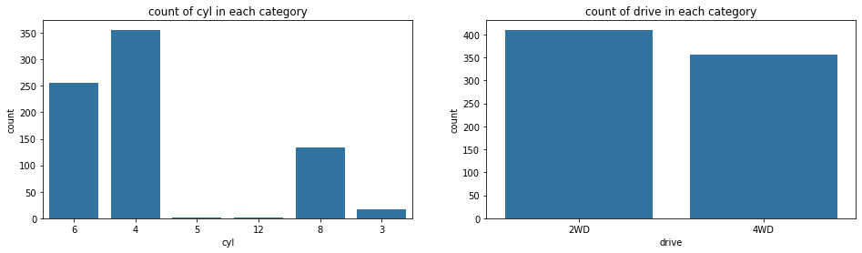

### for number of engine cylinders (cly) cylinder with number 4 is the most and 5 and 12 are minimum count of cars in our dataset. about the number of wheel drive, number of car in 2WD is more than 4WD

## what is the distribution of each numeric variable? (behaviour of variable)

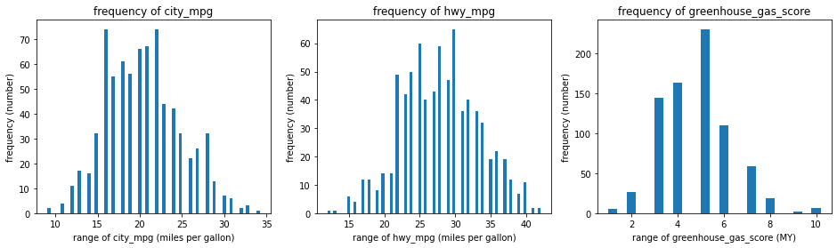

### distribution of city_mpg is look alike normal distribution.maximum city_mpg is happened in mean of data that is close to median of data (between 15 to 22). minimum of number of cars are close to 10 and 33. like city_mpg, we have similar analysis for hwy_mpg. maximum range of it occured between 25 to 30. for greenhouse gas score we have distribution like normal as well. maximum number score is about 5 and minimum score is about 9 and 1

## overview correlations present between features in the data

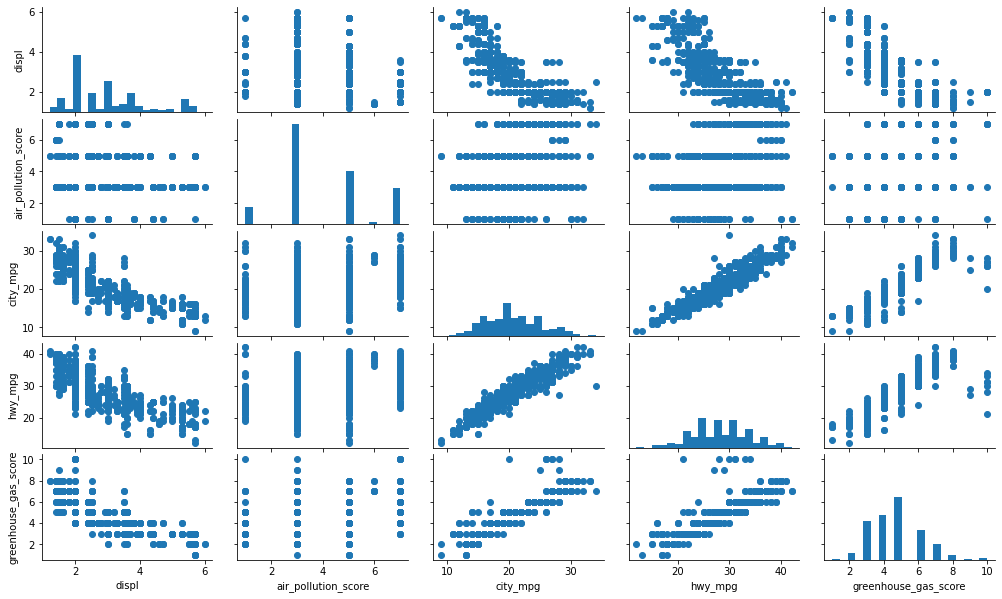

### city_mpg and hwy_mpg are highly correlated. both of these variable are about fuel economy in miles per gallon and it is not surprising to see this high correlation. the correlation between displ and city_mpg and hwy_mpg are negative

## HeatMap correlations present between features in the data

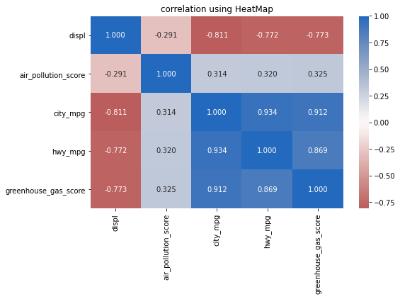

### it shows relationship between numeric variables that we have already mentioned

## comparing number of engine and all numeric variables

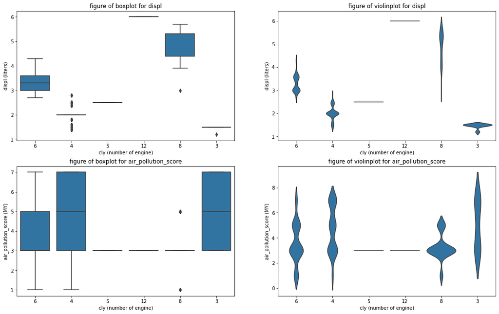

### given these chart, we found first negative and after that positive relation between this variable

## comparing number of fuel and all numeric variables

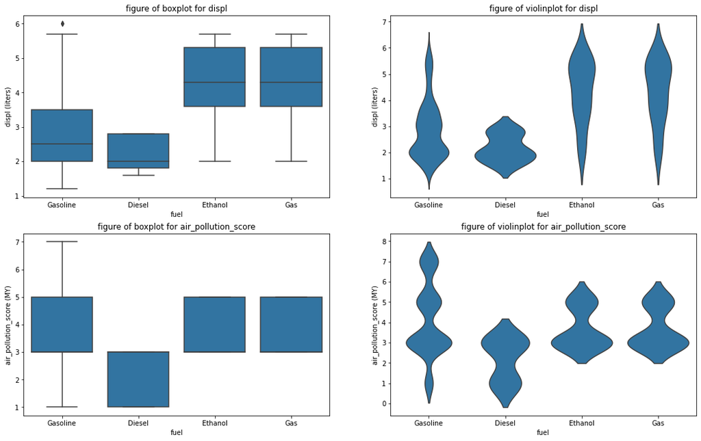

## what is the relationship between two numeric variables in seperate parts of ordinal variabls?

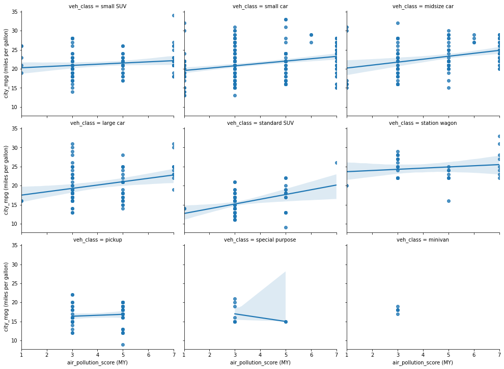

### we can see in these charts that we do not have strong relation between air pollution and city mpg. but for small car, midsize car, large car and standard SUV this relation is rarely positive

## what is the relationship between one numeric variable and one ordinal variable in seperate parts of other ordinal variable?

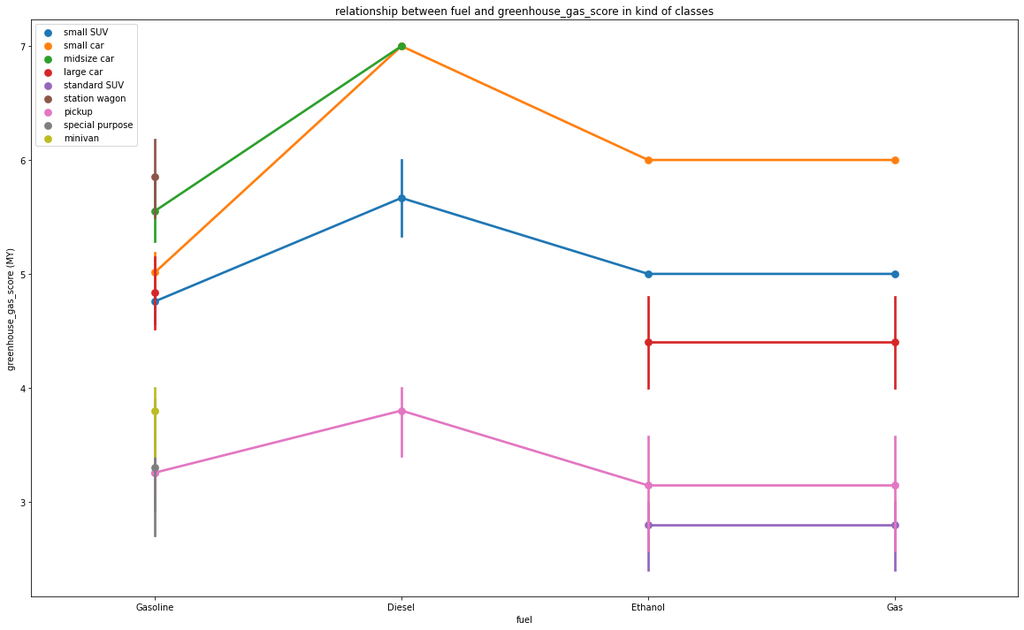